# Random Variables

Statistics I

Paulo Fagandini

Lisbon Accounting and Business School – Polytechnic University of Lisbon

## Disclaimer

These slides are a free translation and adaptation from the slide deck for Estatística I by Prof. Sandra Custódio and Prof. Teresa Ferreira from the Lisbon Accounting and Business School - Polytechnical University of Lisbon.

# (Single) Random Variables

## Random Variables

A random variable is a function that will allow us to quantify (transform into a number) each outcome.

**Random Variable**

A **random variable (r.v.)** $X$ is a function $f:\Omega\rightarrow \Omega_X\subset \mathbb{R}$. $\Omega_X$ is known as the support of the r.v. $X$.

$$\omega\in\Omega \overset{X}{\rightarrow} X(\omega)\in\Omega_X\subset\mathbb{R}$$

> $X(\omega)$ is the *image* under $X$ of the outcome $\omega$

Summarizing, a r.v. is a function that associates a real number to each outcome from $\Omega$.

## Random Variables

- $\{X=x\}$, $\{X\leq x\}$, $\{X>x\}$ are events
- $\{X=x\}$ happens when, from our experiment, we obtain $\omega$ such that $X(\omega)=x$. $\{X=x\}=\{\omega\in\Omega | X(\omega)=x\}$
- The probability of $X\leq x$ for example, is then
  $$P(X\leq x)=P\left(\{\omega\in \Omega| X(\omega)\leq x\}\right)$$

# Types of random variables

## Discrete Random Variable

$X$ is a discrete r.v. when:

- The support of $X$, $\Omega_X$, is finite or countable infinite.
- $P(\Omega_X)=1$

> In this case, $\Omega_X=\{x_1, x_2, ... , x_n\}$ with $n\in\mathbb{N}$ if $\Omega_X$ is finite, and $\Omega_X=\{x_1,x_2,...,x_n,...\}$ if it is countable infinite.

## Probability density function (*pdf*)

Let $X$ be a discrete r.v. The *pdf* of $X$ is a function $f_X:\mathbb{R}\rightarrow\mathbb{R}$ such that:

$$f_X(x)=\left\{\begin{array}{cc}P(X=x) & ,\text{ if } x\in\Omega_X\\ 0 & ,\text{ if } x\in\mathbb{R}\setminus\Omega_X\end{array}\right.$$

Naturally, by construction the *pdf* satisfies the following properties:

| $f_X(x)\geq 0 \quad \forall x\in\mathbb{R}$ |
| --- |
| $\sum_{x_i\in\Omega_X}P(X=x_i)=1$ |

## Probability density function (*pdf*)

The *pdf* gives the probability in a single *point*. The total probability is distributed among single points, $x_i$. A reasonable representation of a *pdf* of a discrete r.v. could be:

| $x$ | $x_1$ | $x_2$ | … | $x_n$ | … |
| --- | --- | --- | --- | --- | --- |
| $f(x)$ | $p_1$ | $p_2$ | … | $p_n$ | … |

Where $p_i=P(X=x_i)$

## Example

Consider the discrete r.v. $X$ with the following *pdf*:

| $x$ | 0 | 1 | 2 | 3 | 4 |
| --- | --- | --- | --- | --- | --- |
| $f(x)$ | $0.05$ | $a$ | $0.35$ | $0.25$ | $0.05$ |

We could define:

- Support of $X$: $\Omega_X=\{0,1,2,3,4\}$
- $\sum_{x\in\Omega_X} f(x)=1 \Rightarrow 0.05 + a + 0.35 + 0.25 + 0.05 = 1$ that is $a=$
- 0.3

## Example

Our table is now:

| $x$ | 0 | 1 | 2 | 3 | 4 |
| --- | --- | --- | --- | --- | --- |
| $f(x)$ | $0.05$ | $0.3$ | $0.35$ | $0.25$ | $0.05$ |

What is $P(X=2|X\leq 3)$?

$$P(X=2|X\leq 3)=\frac{P(X=2 \cap X\leq 3)}{P(X\leq 3)}= \frac{P(X=2)}{P(X\leq 3)}$$

$$= \frac{f(2)}{f(0)+...+f(3)}=\frac{0.35}{0.95}=0.368$$

## Continuous random variables

$X$ is a continuous r.v. if:

- The support of $X$, $\Omega_X$ is uncountable infinite.
- $P(\Omega_X)=1$
- $P(X=x)=0$ $\forall x\in\mathbb{R}$.

## Probability density function (*pdf*)

Let $X$ a continuous r.v.

> Technically, from Measure Theory, we need an *absolutely continuous* r.v. to ensure the existence of a *pdf*. These issues are beyond the scope of this course. Just know that when we say *continuous* r.v. we mean *absolutely continuous* r.v.

## Probability density function (*pdf*)

Note that this *pdf* allows to compute the probability of events $x\in(a,b]$:

$$P(a<X\leq b)=\int_a^b f_X(x)dx$$

Observe that if you would do $X=a$ you would get the integral from $a$ to $a$, which makes $dx=0$ and therefore the integral (and the probability) becomes 0.

## Example

Let $X$ be a continuous r.v. with the following *pdf*:

$$f(x)=\left\{\begin{array}{cc}
\theta x^2 & , 0\leq x< 1\\ 0 & ,\mathbb{R}\setminus [0,1)
\end{array}\right.$$

- Support for $X$: $\Omega_X=[0,1)$
- $$\int_{-\infty}^{\infty}f(x)dx=1\Leftrightarrow\int_0^1\theta x^2dx=\left[\theta\frac{x^3}{3}\right]_{0}^1$$
- $$\theta\frac{1}{3}-\theta\frac{0}{3}=1\Leftrightarrow \theta=3$$

## Cumulative distribution function (*cdf*)

Let $X$ be a r.v. The **distribution function** $F_X:\mathbb{R}\rightarrow[0,1]$, defined as:

$$F_X(x)=P(X\leq x)$$

$F_x$ is unique.

## Cumulative distribution function (*cdf*)

With a discrete r.v.

| $x$ | 0 | 1 | 2 | 3 | 4 |
| --- | --- | --- | --- | --- | --- |
| $f(x)$ | $0.05$ | $0.3$ | $0.35$ | $0.25$ | $0.05$ |

$$F(x)=P(X\leq x)=\left\{
\begin{array}{cc}
0 & x<0 \\
0.05 & 0\leq x < 1 \\
0.05 + 0.3 = 0.35 & 1 \leq x < 2 \\
0.35 + 0.35 = .7 & 2 \leq x < 3 \\
0.7 + 0.25 = .95 & 3 \leq x < 4 \\
1 & x\geq 4
\end{array}
\right.$$

## Cumulative distribution function (*cdf*)

Let’s revisit our previous example:

$$P(X=2|X\leq 3)=
\frac{P(X=2)}{P(X\leq 3)}=$$
$$\frac{F(2)-F(2^-)}{F(3)}=
\frac{0.7-0.35}{0.95}=0.368$$

## Cumulative distribution function (*cdf*)

With a continuous r.v.:

$$F_X(x)=P(X\leq x)=\int_{-\infty}^{x} f_X(x)dx$$

The distribution function, $F_X$ allows to compute the probability of $\{X\in(a,b]\}$

$$P(a<X\leq b)=\int_a^b f_X(x)dx=F_X(b)-F_X(a)$$

## Example

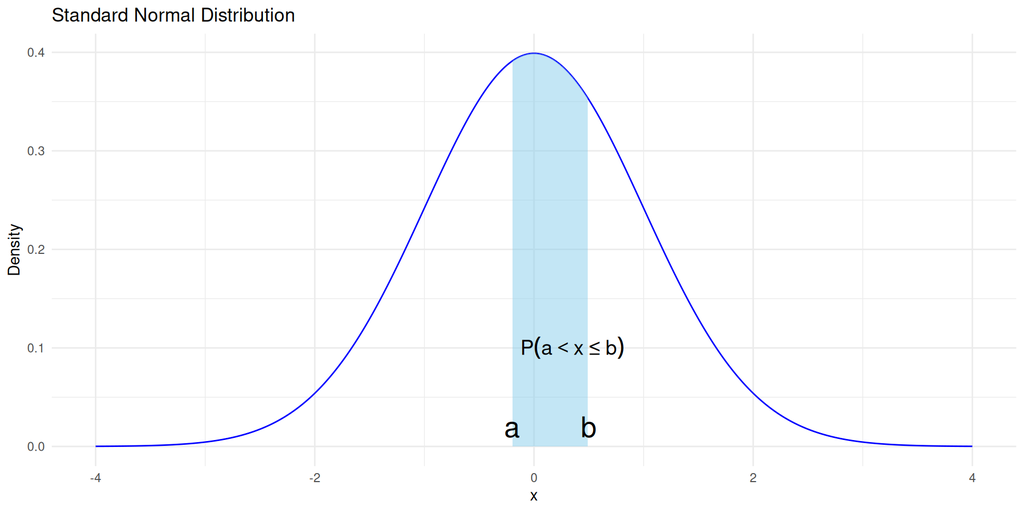

## Example

Consider the continuous r.v. defined previously, with the *pdf*:

$$f(x)=\left\{
\begin{array}{cc}
3x^2 & , 0\leq x< 1\\
0 & , \mathbb{R}\setminus [0,1)
\end{array}
\right.$$

Support for $X$: $\Omega_X=[0,1)$

Distribution function (*cdf*):

$$F(x)=P(X\leq x) = \int_{-\infty}^x f(t)dt = \left\{
\begin{array}{cc}
0 & , x<0\\
x^3 & ,0\leq x<1 \\
1& ,x\geq 1
\end{array}
\right.$$

## Properties of the *cdf*

Nonetheless the r.v. is discrete or continuous, $F_X$ has the following properties:

- $F_X:\mathbb{R}\rightarrow[0,1]$
- $F_X$ is continuous from the right: $\lim_{x\rightarrow a^+}F_X(x)=F(a)$
- $F_X$ is monotone non-decreasing.
- $\lim_{x\rightarrow -\infty} F_X(x)=0$
- $\lim_{x\rightarrow \infty} F_X(x)=1$

## Properties of the *cdf*

$F_X$ for $X$ r.v. continuous

- Continuous support $\Omega_X$
- It is continuous in $\mathbb{R}$
- $P(X<x)=P(X\leq x)=F(x)$
- $P(a\square X\square b)=F(b)-F(a)$, [replace $\square$ for $<$ or $\leq$]

## *pdf* and *cdf*

For a discrete r.v.

$$P(X=x)=F_X(x)-F_X(x^-)$$
$$+\downarrow \uparrow -$$
$$F_X(x)=\sum_{x_i\leq x}P(X=x_i)$$

## *pdf* and *cdf*

For a continuous r.v.

$$f_X(x)=\left\{
\begin{array}{cc}
F_X'(x) & ,x\in\mathbb{R} \text{ if }F_X'\text{ exists} \\
0 & \text{, otherwise}
\end{array}
\right.$$

$$Derivative \downarrow \uparrow Primitive$$

$$F_X(x)=\int_{-\infty}^x f_X(t)dt$$

> The *pdf* of $X$, a continuous r.v. is not unique.

# Statistical Moments of a Population

## Describing a population

We could describe the range of $X$, a r.v., as a population, in the statistical sense, because it describes all the possible values it can take.

We can use numerical values to do so, which can represent dispersion or centrality of the data.

## Expected Value or mean

The expected value or mean, is a location parameter for our r.v.

**Definition**

The **expected value** or **mean** of a random variable $X$ is:

- $\mu_X=E[X]=\sum_{x\in\Omega_X}x P(X=x) < \infty$ if $X$ is discrete
- $\mu_X=E[X]=\int_{-\infty}^{\infty}xf_X(x)dx<\infty$ if $X$ is continuous.

> Not all random variables have an expected value, it might be infinite.

## Expected Value or mean

Let $X,Y$ rvs, and $a,b\in\mathbb{R}$ scalars. Some properties of the mean

1. $E[a]=a$
2. $E[aX+bY]=aE[X]+bE[Y]$
3. If $Y=g(X)$, a r.v.:
   - Discrete, then
     $$E[Y]=\sum_{x\in\Omega_X}g(x)P(X=x)<\infty$$
   - Continuous, then
     $$E[Y]=\int_{-\infty}^{\infty}g(x)f_X(x)dx<\infty$$

## Example discrete

Let $X$ be a discrete r.v. as in the previous example:

| $x$ | 0 | 1 | 2 | 3 | 4 |
| --- | --- | --- | --- | --- | --- |
| $f(x)$ | $0.05$ | $0.3$ | $0.35$ | $0.25$ | $0.05$ |

Let $g(X)=2(X-1)^2+3(X-1)-5$, find $E[g(X)]$.

## Example discrete

$$g(X)=2(X-1)^2+3(X-1)-5$$
$$=2(X^2-2X+1)+3X-3-5$$
$$=2X^2-4X+2+3X-8$$
$$=2X^2-X-6$$

$$E[Y]=E[2X^2-X-6]$$

$$=2E[X^2]-E[X]-6$$

## Example discrete

We only need to find $E[X]$ and $E[X^2]$ to obtain $E[g(X)]$.

$$E[X]=\sum xP(X=x)$$
$$= 0\times .05 + 1 \times .3 + 2 \times .35 + 3 \times .25 + 4\times .05 = 1.95$$

$$E[X^2]=\sum x^2 P(X=x)$$

$$= 0\times .05 + 1 \times .3 + 4 \times .35 + 9 \times .25 + 16\times .05 = 4.75$$

$$E[g(X)]=2\times 4.75 - 1.95 - 6 = 1.55$$

## Example continuous

Recall our example for continuous r.v.s. $X$:
$$f_X(x)=\left\{
\begin{array}{cc}
3x^2 & ,0\leq x < 1 \\
0 & , \mathbb{R}\setminus[0,1)
\end{array}
\right.$$

Find $E[g(X)]$ when $g(X)=2(X-1)^2+3(X-1)-5$ We know already $g(X)=2X^2-X-6$. Let’s focus on $E[x]$ and $E[X^2]$.

## Example continuous

$$E[X]=\int_{-\infty}^{\infty} xf_X(x)dx = \int_0^1 x\times 3x^2 dx$$
$$= \int_0^1 3x^3dx=\left[3\frac{x^4}{4}\right]_{0}^1=\frac{3}{4}=0.75$$

$$E[X^2]=\int_{-\infty}^{\infty} x^2f_X(x)dx = \int_0^1 x^2\times 3x^2 dx$$
$$= \int_0^1 3x^4dx=\left[3\frac{x^5}{5}\right]_{0}^1=\frac{3}{5}=0.6$$

## Example continuous

Finally,

$E[g(x)]=2\times 0.6 - 0.75 - 6 = -5.55$

## p-quantile

The p-quantile, $x_p$, of a r.v. $X$ is a location parameter, with fixed value.

## p-quantile for discrete r.v.

$x_p$ is the value for $x\in\Omega_X$ such that:

1. $P(X\leq x)\geq p$
2. $P(X\geq x)\geq 1-p$

O what is the same, $x\in\Omega_X$ such that $F_X(x^-)\leq p \leq F_X(x)$

## p-quantile for continuous r.v.

$x_p$ is an $x\in\Omega_X$ such that $F_X(x)=p$

Let’s apply this for the examples we just used for the expected value.

## Example - Discrete

Find the median (0.5-quantile) for $X$

$$F(x)=P(X\leq x)=\left\{
\begin{array}{cc}
0 &, x\leq 0\\
0.05 &, 0\leq x <1 \\
0.35 &, 1\leq x < 2 \\
0.7 &, 2 \leq x < 3 \\
0.95 &, 3 \leq x < 4 \\
1 &, x\geq 4
\end{array}
\right.$$

For example $F(2^-)=0.35\leq 0.5 \leq 0.7=F(2)$ and therefore $X_{0.5}=Me = 2$. Given that $E[X]=1.95<Me(X)=2$ the distribution is slightly negatively (or left) skewed.

## Example - Continuous

$$F_X(x)=P(X\leq x)=\left\{
\begin{array}{cc}
0 & x < 0 \\
x^3 & 0\leq x <1 \\
1 & x\geq 1
\end{array}
\right.$$

Let’s find $x$ such that $F(x)=0.5$

$F(x)=0.5\Leftrightarrow x^3=0.5\Leftrightarrow x=\sqrt[3]{0.5}\approx0.7937$

And therefore, $x_{0.5}=Me=.7937$

## Variance

Let $X$ be a r.v. The **variance** of $X$, if it exists, is defined as:

$$V[X]=E\left[\left(X-E[X]\right)^2\right]$$

It can be show, very easily, with some algebraic manipulation that $V[x]=E\left[X^2\right]-\left(E[X]\right)^2$

## Variance

Remember that $E[X]\equiv\mu_X$

1. For a discrete r.v.:
   $$V[X]=\sum_{x\in\Omega_X}(x-\mu_X)^2P(X=x)$$
2. For a continuous r.v.:
   $$V[X]=\int_{-\infty}^{\infty}(x-\mu_X)^2f_X(x)dx$$

Usually we write $V[X]$ as $\sigma^2_X$.

## Variance

Some properties for the variance:

1. $V[a]=0$ for $a\in\mathbb{R}$
2. $V[aX+b] = a^2V[X]$ for $a,b\in \mathbb{R}$ and $X$ a r.v.
3. If $X$ and $Y$ are independent r.v. with finite variance, then
   $$V[X\pm Y]=V[X]+V[Y]$$

## Standard deviation $\sigma_X$

If $\sigma^2_X$ is the variance of $X$, then the standard deviation is known as:
$$\sigma_X=\sqrt{V[x]}$$

One characteristic of the standard deviation is that its units are the same as those of the random variable.

## Coefficient of variation

While the variance and standard deviation allow us to measure the dispersion of the data, we might want to have it relative to the mean (a $\sigma_X=1$ can be a lot for $X$ taking relatively low values, but negligible if we are talking in millions!)

For that we use the coefficient of variation:

$$C.V._X =\frac{\sigma_X}{\mu_X}\times 100$$

## Coefficient of variation

Some properties of the $CV_X$

1. It is not defined for $\mu_X=0$
2. Lower values for $CV_X$ means less dispersion around $\mu_X$, therefore, more precision.
3. $CV_X$ could be a measure for risk, if we are looking at returns for some asset.
4. $CV_X$ is the relative weight of deviations from the mean, over the mean itself.

## Example

Let’s compute $\sigma^2$, $\sigma$, and $CV$ for our previous examples:

1. $V[X]=E[X^2]-\mu_X^2=4.75-1.95^2=0.9475$
2. $\sigma=\sqrt{V[X]}=\sqrt{0.9475}=0.97$
3. $CV=\frac{\sigma}{\mu}\times 100 = \frac{0.97}{1.95}\times 100 = 49.7\%$

Values below $50\%$ for $CV$ allow us to see $\mu$ as representative for the data. The lower, the closer the data to $\mu$ and therefore the more representative it is.

## Example

For the continuous r.v. case:

1. $V[X]=E[X^2]-\mu_X^2=0.6-0.75^2=0.0375$
2. $\sigma=\sqrt{V[X]}=\sqrt{0.0375}=0.1936$
3. $CV=\frac{\sigma}{\mu}\times 100 = \frac{0.1936}{0.75}\times 100=25.81\% < 50\%$

# Random Pairs

## Random pair

When running an experiment, it could be interesting to study the relationship between *two numeric features associated to each of the outcomes.*

**Random pair**

A random pair $(X,Y)$ is a function $f_{X,Y}:\Omega\rightarrow \left(\Omega_X,\Omega_Y\right)\subset\mathbb{R}^2$. $\left(\Omega_X, \Omega_Y\right)$ is known as the support of the random pair $(X,Y)$.

$$\omega\in\Omega \overset{(X,Y)}{\rightarrow}\left(X(\omega),Y(\omega)\right)\in(\Omega_X,\Omega_Y)\subset\mathbb{R}^2$$

$X(\omega)$ is the image, under $X$ of outcome $\omega$, and $Y(\omega)$ the image under $Y$ of the same outcome.

## Discrete random pair

A random pair $(X,Y)$ is discrete when:

- The support $(X,Y)$, $(\Omega_X,\Omega_Y)$, is a finite or countable infinite of pairs.
- $P\left(\Omega_X,\Omega_y\right)=1$

## Joint density function $f_{X,Y}$

Let $(X,Y)$ a discrete random pair, the joint density function $f_{X,Y}(x,y)$ is a function $f_{X,Y}:\mathbb{R}^2\rightarrow\mathbb{R}$ defined as:

$$f_{X,Y}(x,y)=\left\{
\begin{array}{cl}
P(X=x,Y=y) & , (x,y)\in(\Omega_X,\Omega_Y)\\
0 & , (x,y)\in\mathbb{R}^2\setminus(\Omega_X,\Omega_Y)
\end{array}
\right.$$

## Joint density function $f_{X,Y}$

$f_{X,Y}$ satisfies the following properties:

1. $f_{X,Y}(x,y)\geq 0\forall(x,y)\in\mathbb{R}^2$
2. $\sum_{x_i\in\Omega_X}\sum_{y_j\in\Omega_Y}P\left(X=x_i,Y=y_j\right)=1$ $\forall i,j=1,2,...$

> A possible notation for $P(X=x_i,Y=y_j)$ is $p_{i,j}$

## Joint density function $f_{X,Y}$

|  | $y_1$ | $y_2$ | $\dots$ | $y_j$ | $\dots$ |  |
| --- | --- | --- | --- | --- | --- | --- |
| $x_1$ | $p_{11}$ | $p_{12}$ | $\dots$ | $p_{1j}$ | $\dots$ | $\sum_{j=1}^\infty p_{1j}$ |
| $x_2$ | $p_{21}$ | $p_{22}$ | $\dots$ | $p_{2j}$ | $\dots$ | $\sum_{j=1}^\infty p_{2j}$ |
| $\vdots$ | $\vdots$ | $\vdots$ | $\ddots$ | $\vdots$ | $\ddots$ | $\vdots$ |
| $x_i$ | $p_{i1}$ | $p_{i2}$ | $\dots$ | $p_{ij}$ | $\dots$ | $\sum_{j=1}^\infty p_{ij}$ |
| $\vdots$ | $\vdots$ | $\vdots$ | $\ddots$ | $\vdots$ | $\ddots$ | $\vdots$ |
|  | $\sum_{i=1}^\infty p_{i1}$ | $\sum_{i=1}^\infty p_{i2}$ | $\dots$ | $\sum_{i=1}^\infty p_{ij}$ | $\dots$ | 1 |

## Marginal probability function

Given a random pair $(X,Y)$, the **marginal probability function** of $X$ and $Y$ is respectively:

- $f_X(x_i) = P(X=x_i)=$
  $$\sum_{j=1}^\infty P(X=x_i, Y=y_j) = \sum_{j=1}^\infty p_{ij}$$
- $f_Y(y_j) = P(Y=x_j)=$
  $$\sum_{i=1}^\infty P(X=x_i, Y=y_j) = \sum_{i=1}^\infty p_{ij}$$

For $i=1,2,...$ and $j=1,2,...$. Note that these functions have one dimension only.

## Example

At SuperStore 🏪, three trained employees are qualified to operate the checkout counters, restock products on the shelves, and perform some administrative tasks. SuperStore has three checkout counters, and at least one of them must always be operating.

At any given day and moment when SuperStore is open to customers, consider the following random variables:

- $X$ N of employees in the checkout counters 🛒 💳 .
- $Y$ N of employees restocking products on the shelves 📦.

## Example

The r.v. $X$ has $\Omega_X=\{1,2,3\}$ and the following *pdf*:

| $x$ | 1 | 2 | 3 |
| --- | --- | --- | --- |
| $f_X(x)$ | 0.17 | 0.8 | 0.03 |

Consider the following table for the joint probability of $(X,Y)$

| $X\setminus Y$ | 0 | 1 | 2 |  |
| --- | --- | --- | --- | --- |
| 1 | $a$ | $2b$ | $b$ |  |
| 2 | 0.1 | $c$ | 0 |  |
| 3 | 0.03 | 0 | 0 |  |
|  |  |  |  | 1 |

## Example

| $X\setminus Y$ | 0 | 1 | 2 | $\color{red}{f_X(x)}$ |
| --- | --- | --- | --- | --- |
| 1 | $\color{red}{0.02}$ | $2b$ | $b$ | $\color{red}{0.17}$ |
| 2 | 0.1 | $c$ | 0 | $\color{red}{0.8}$ |
| 3 | 0.03 | 0 | 0 | $\color{red}{0.03}$ |
| $\color{red}{f_Y(y)}$ | $\color{red}{0.15}$ | $\color{red}{2b+c}$ | $\color{red}{b}$ | 1 |

- From first row: $0.02 + 2b + b = 0.17$ $\Rightarrow$ $b=\frac{0.15}{3}=0.05$
- From second row: $0.1 + c = 0.8$ $\Rightarrow$ $c=0.7$

## Example

2. $P(X=2|Y\geq 1)$ is approximately…?
   - $$P(X=2|Y\geq 1)=\frac{P(X=2, Y\geq 1)}{P(Y\geq 1)}$$
   - $$= \frac{P(X=2, Y=1) + P(X=2, Y=2)}{P(Y=1)+P(Y=2)}$$
   - $$\frac{0.7+0}{0.8+0.05}=\frac{0.7}{0.85}\approx 0.8235$$

## Independence of random variables (revisited)

Let $(X,Y)$ a discrete random pair, $X,Y$ are independent if, and only if:
$$P(X=x, Y=y)=P(X=x)P(Y=y)\quad \forall(x,y)\in\mathbb{R}^2$$

> The joint *cdf* is the same as the product of each marginal *pdf*

## Example

3. … (continued exercise) Are $X$ and $Y$ independent?
   - $P(X=2, Y=2)=0$
   - $P(X=2)P(Y=2)= 0.8 \times 0.05=0.04$
   - $0\neq 0.04$
   - $X$ and $Y$ are not independent.

## Moments of a random pair

**Definition**

Let the discrete random pair $(X,Y)$ have a joint $cdf$ $P(X=x,Y=y)$ and a function $g:\mathbb{R}^2\rightarrow\mathbb{R}$. The **expected value or mean** of $g(X,Y)$ is:

$$E[g(X,Y)]=\sum_{i=1}^\infty\sum_{j=1}^\infty g(x_i,y_j)P(X=x_i,Y=y_j)$$

> If $g(x,y)=xy$, then $E[g(x,y)]=E[XY]$ and that equals
> $$\sum_{i=1}^\infty\sum_{j=1}^\infty x_iy_jP(x=x_i,Y=y_j)$$

## Moments of a random pair

**Definition**

Let the discrete random pair $(X,Y)$ have a joint $cdf$ $P(X=x,Y=y)$, and $\mu_X=E[X]$ and $\mu_Y=E[Y]$. The **covariance** between $X$ and $Y$ is:

$$cov(X,Y)=E[(X-\mu_X)(Y-\mu_Y)]$$

Given that $E[(X-\mu_X)(Y-\mu_Y)]$ exists.

> Note that this is equivalent to $cov(X,Y)=E[XY]-E[X]E[Y]$

## Properties of the covariance

The covariance tries to capture how the two r.v. move together. If it is positive, it means that both tend to go in the same direction more often than not (both above or below their means at the same time). Being negative means that more often than not when one is above its mean, the other is below.

1. $cov(X,Y)=cov(Y,X)$
2. $cov(X,X)=V[X]$ and $cov(Y,Y)=V[Y]$ if $V[X]$ and $V[Y]$ exist.
3. $cov(a+bX, c+dY)=bd cov(X,Y)$ with $a,b,c,e\in\mathbb{R}$

## Properties of the covariance

If $X$ and $Y$ are independent r.v. then $cov(X,Y)=0$. Note that the opposite is not necessarily true, i.e. $cov(X,Y)=0$ does not imply that $X$ and $Y$ are independent.

Another important identity with the covariance is the following:

$$V[X\pm Y] = V[X]+V[Y]\pm 2 cov(X,Y)$$

## Example

Knowing that $E[Y]=0.9$, $cov(X,Y)$ is equal to? …

- From the first table: $E[X]=0.17\times 1 + 0.8 \times 2 + 0.03 \times 3 = 1.86$
- $$E[XY]=\sum_{x}\sum_{y}xyP(X=x,Y=y)=$$
  $$= 1 \times 0 \times 0.02 + 1\times 1 \times 0.1 + 1\times 2 \times 0.05 +$$
  $$+ 3\times 0 \times 0.1 + 2 \times 1 \times 0.7 + 2\times 2 \times 0 +$$
  $$+ 3 \times 0 \times 0.03 + 3 \times 1 \times 0 + 3 \times 2 \times 0 = 1.6$$
- $cov(X,Y)=E[XY]-E[X]E[Y]=1.6-1.86\times 0.9=-0.074$

## Correlation coefficient

A caveat of the covariance is that its units depends directly on the units of $X$ and $Y$. The correlation coefficient allow us to express this relationship, between $X$ and $Y$ without being affected by the units in which these r.v. are measured.

$$\rho_{XY} = \frac{cov(X,Y)}{\sqrt{V[X]V[Y]}}=\frac{cov(X,Y)}{\sigma_X\sigma_Y}$$

Clearly $\rho\in[-1,1]$. Note also that $|\rho|=1$ if and only if $P(Y=a+bX)=1$ with $a,b\in\mathbb{R}$. If $X$ and $Y$ are independent r.v. then $\rho=0$.

## Correlation coefficient

| Correlation coefficient | Correlation |
| --- | --- |
| $\|\rho\| = 1$ | Perfect |
| $0.8 \leq \|\rho\| < 1$ | Strong |
| $0.5 \leq \|\rho\| < 0.8$ | Moderate |
| $0.1 \leq \|\rho\| < 0.5$ | Weak |
| $0 < \|\rho\| < 0.1$ | Very weak |
| $\rho= 0$ | None |

Write *positive* or *negative* in front of correlation if $\rho>0$ or $\rho<0$ respectively.

## Example

5. Based on the previous question, find the correlation coefficient between $X$ and $Y$.
- From the marginal probability function we obtain $V[X]$ and $V[Y]$:
  $$V[X]=0.1804\text{ and }V[Y]=0.19$$
- Therefore,
  $$\rho = \frac{cov(X,Y)}{\sigma_X\sigma_Y}=\frac{-0.074}{\sqrt{0.1804}\sqrt{0.19}}=-0.3997$$
- We observe a weak negative linear correlation between $X$ and $Y$.

## Bibliography

- Figueiredo, F., Figueiredo, A., Ramos, A. & Teles, R. (2009). Estatística Descritiva e Probabilidades (2<sup>a</sup> Edição). Escolar Editora.
- Murteira, B., Ribeiro, C.R., Silva, J.R. & Pimenta, C. (2007). Introdução à Estatística (2<sup>a</sup> Edição). McGraw-Hill.
- Pestana, D. & Velosa, S.F. (2008). Introdução à Probabilidade e à Estatística (3<sup>a</sup> Edição). Fundação Calouste Gulbenkian.
- Paulino, C.D. & Branco, J.A. (2005). Exercícios de Probabilidade e Estatística. Escolar Editora.